# methylation_array_analysis 2024

This is the factor of interest

```r
cellType <- factor(targets$Sample_Group)
```

This is the individual effect that we need to account for

```r
individual <- factor(targets$Sample_Source)
```

Use the above to create a design matrix

```r
design <- model.matrix(~0+cellType+individual, data=targets)
colnames(design) <- c(levels(cellType),levels(individual)[-1])
```

Fit the linear model using limma

```r
fit <- lmFit(mVals, design)
```

Create a contrast matrix for specific comparisons

```r
contMatrix <- makeContrasts(naive-rTreg,
                           naive-act_naive,
                           rTreg-act_rTreg,
                           act_naive-act_rTreg,
                           levels=design)
contMatrix
```

```
##            Contrasts
## Levels      naive - rTreg naive - act_naive rTreg - act_rTreg
##   act_naive             0                -1                 0
##   act_rTreg             0                 0                -1
##   naive                 1                 1                 0
##   rTreg                -1                 0                 1
##   M29                   0                 0                 0
##   M30                   0                 0                 0
##            Contrasts
## Levels      act_naive - act_rTreg
##   act_naive                     1
##   act_rTreg                    -1
##   naive                         0
##   rTreg                         0
##   M29                           0
##   M30                           0
```

7.2 Fit the contrasts in limma, and perform differential methylation (DM) analysis

```r
fit2 <- contrasts.fit(fit, contMatrix)
fit2 <- eBayes(fit2)
```

Look at the numbers of DM CpGs at FDR < 0.05

```r
summary(decideTests(fit2))
```

```
##        naive - rTreg naive - act_naive rTreg - act_rTreg act_naive - act_rTreg
## Down            1606               408                 0                   552
## NotSig        426397            428759            429397                427943
## Up              1394               230                 0                   902
```

Get the table of results for the first contrast (naive - rTreg)

```r
ann450kSub <- ann450k[match(rownames(mVals),ann450k$Name),
                      c(1:4,12:19,24:ncol(ann450k))]
DMPs <- topTable(fit2, num=Inf, coef=1, genelist=ann450kSub)
head(DMPs)
```

```
##              chr       pos strand       Name Probe_rs Probe_maf CpG_rs CpG_maf
## cg07499259  chr1  12188502      + cg07499259     <NA>        NA   <NA>      NA
## cg26992245  chr8  29848579      - cg26992245     <NA>        NA   <NA>      NA
## cg09747445 chr15  70387268      - cg09747445     <NA>        NA   <NA>      NA
## cg18808929  chr8  61825469      - cg18808929     <NA>        NA   <NA>      NA
## cg25015733  chr2  99342986      - cg25015733     <NA>        NA   <NA>      NA
## cg21179654  chr3 114057297      + cg21179654     <NA>        NA   <NA>      NA
##            SBE_rs SBE_maf            Islands_Name Relation_to_Island
## cg07499259   <NA>      NA                                    OpenSea
## cg26992245   <NA>      NA                                    OpenSea
## cg09747445   <NA>      NA chr15:70387929-70393206            N_Shore
## cg18808929   <NA>      NA  chr8:61822358-61823028            S_Shelf
## cg25015733   <NA>      NA  chr2:99346882-99348177            N_Shelf
## cg21179654   <NA>      NA                                    OpenSea
##                                           UCSC_RefGene_Name
## cg07499259                                  TNFRSF8;TNFRSF8
## cg26992245
## cg09747445                                   TLE3;TLE3;TLE3
## cg18808929
## cg25015733                                           MGAT4A
## cg21179654 ZBTB20;ZBTB20;ZBTB20;ZBTB20;ZBTB20;ZBTB20;ZBTB20
##                                                                             UCSC_RefGene_Accession
## cg07499259                                                                     NM_152942;NM_001243
## cg26992245
## cg09747445                                                        NM_001105192;NM_020908;NM_005078
## cg18808929
## cg25015733                                                                               NM_012214
## cg21179654 NM_001164343;NM_001164346;NM_001164345;NM_001164342;NM_001164344;NM_001164347;NM_015642
##                                   UCSC_RefGene_Group Phantom DMR Enhancer
## cg07499259                                5'UTR;Body
## cg26992245                                                           TRUE
## cg09747445                            Body;Body;Body
## cg18808929                                                           TRUE
## cg25015733                                     5'UTR
## cg21179654 3'UTR;3'UTR;3'UTR;3'UTR;3'UTR;3'UTR;3'UTR
##                     HMM_Island Regulatory_Feature_Name
## cg07499259 1:12111023-12111225
## cg26992245
## cg09747445
## cg18808929
## cg25015733
## cg21179654                       3:114057192-114057775
##                   Regulatory_Feature_Group DHS     logFC     AveExpr         t
## cg07499259                                      3.654104  2.46652171  18.77533
## cg26992245                                      4.450696 -0.09180715  18.35830
## cg09747445                                     -3.337299 -0.25201484 -18.29169
## cg18808929                                     -2.990263  0.77522878 -17.95543
## cg25015733                                     -3.054336  0.83280190 -17.37376
## cg21179654 Unclassified_Cell_type_specific      2.859016  1.32460816  17.33058
##                 P.Value   adj.P.Val        B
## cg07499259 7.038346e-08 0.005176247 7.491458
## cg26992245 8.386780e-08 0.005176247 7.394212
## cg09747445 8.627940e-08 0.005176247 7.378282
## cg18808929 9.970727e-08 0.005176247 7.296126
## cg25015733 1.288536e-07 0.005176247 7.146883
## cg21179654 1.313725e-07 0.005176247 7.135430
```

The resulting data.frame can easily be written to a CSV file, which can be opened in Excel.

```r
write.table(DMPs, file="DMPs.csv", sep=",", row.names=FALSE)
```

7.3 plot the top 4 most significantly differentially methylated CpGs

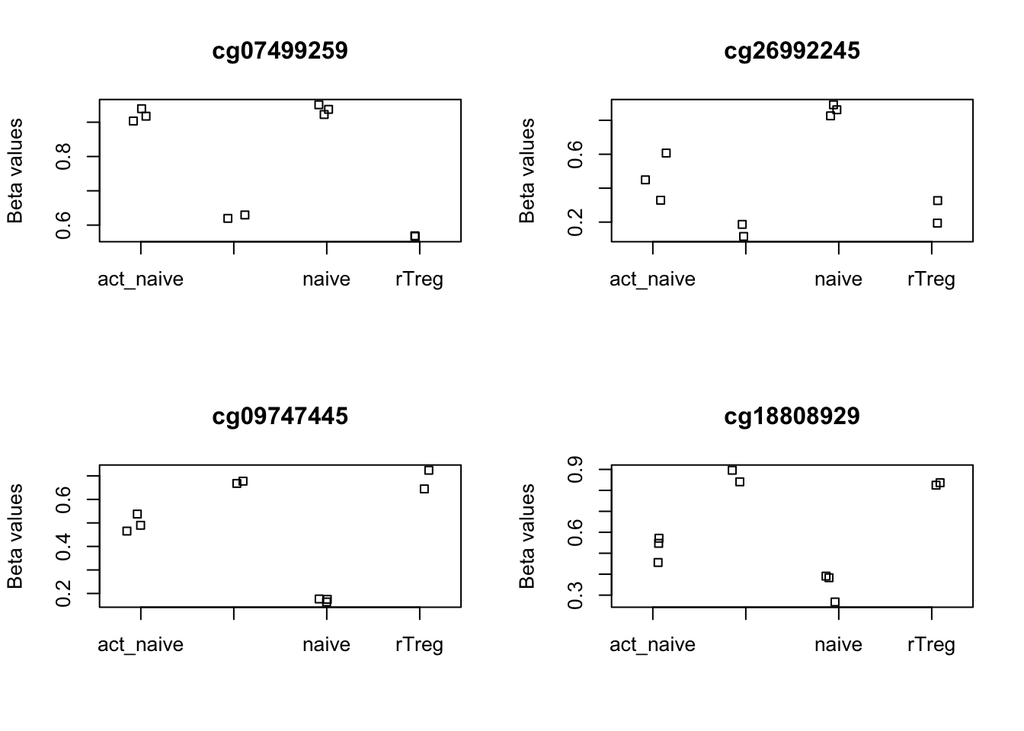

```r
par(mfrow=c(2,2))
sapply(rownames(DMPs)[1:4], function(cpg){
  plotCpg(bVals, cpg=cpg, pheno=targets$Sample_Group, ylab = "Beta values")
})
```

8. Differential methylation analysis of regions

Although performing a probe-wise analysis is useful and informative, sometimes we are interested in knowing whether several proximal CpGs are concordantly differentially methylated, that is, we want to identify differentially methylated regions.

In this workflow, we will perform an analysis using the dmrcate. As it is based on limma, we can directly use the design and contMatrix we previously defined.

Firstly, our matrix of M-values is annotated with the relevant information about the probes such as their genomic position, gene annotation, etc. By default, this is done using the ilmn12.hg19 annotation, but this can be substituted for any argument compatible with the interface provided by the minfi package. The limma pipeline is then used for differential methylation analysis to calculate moderated t-statistics.

```r
myAnnotation <- cpg.annotate(object = mVals, datatype = "array", what = "M",
                             analysis.type = "differential", design = design,
                             contrasts = TRUE, cont.matrix = contMatrix,
                             coef = "naive - rTreg", arraytype = "450K")
```

```
## Your contrast returned 3000 individually significant probes. We recommend the default setting of pcutoff in dmrcate().
```

```r
str(myAnnotation)
```

```
## Formal class 'CpGannotated' [package "DMRcate"] with 2 slots
##   ..@ ranges:Formal class 'GRanges' [package "GenomicRanges"] with 7 slots
##   .. .. ..@ seqnames       :Formal class 'Rle' [package "S4Vectors"] with 4 slots
##   .. .. .. .. ..@ values         : Factor w/ 22 levels "chr1","chr2",..: 1 2 3 4 5 6 7 8 9 10 ...
##   .. .. .. .. ..@ lengths        : int [1:22] 42733 31682 23086 18431 22093 32652 26437 18956 8961 22163 ...
##   .. .. .. .. ..@ elementMetadata: NULL
##   .. .. .. .. ..@ metadata       : list()
##   .. .. ..@ ranges         :Formal class 'IRanges' [package "IRanges"] with 6 slots
##   .. .. .. .. ..@ start          : int [1:429397] 15865 534242 710097 714177 720865 758829 763119 779995 805102 805338 ...
##   .. .. .. .. ..@ width          : int [1:429397] 1 1 1 1 1 1 1 1 1 1 ...
##   .. .. .. .. ..@ NAMES          : chr [1:429397] "chr1:15865" "chr1:534242" "chr1:710097" "chr1:714177" ...
##   .. .. .. .. ..@ elementType    : chr "ANY"
##   .. .. .. .. ..@ elementMetadata: NULL
##   .. .. .. .. ..@ metadata       : list()
##   .. .. ..@ strand         :Formal class 'Rle' [package "S4Vectors"] with 4 slots
##   .. .. .. .. ..@ values         : Factor w/ 3 levels "+","-","*": 3
##   .. .. .. .. ..@ lengths        : int 429397
##   .. .. .. .. ..@ elementMetadata: NULL
##   .. .. .. .. ..@ metadata       : list()
##   .. .. ..@ seqinfo        :Formal class 'Seqinfo' [package "Seqinfo"] with 4 slots
##   .. .. .. .. ..@ seqnames   : chr [1:22] "chr1" "chr2" "chr3" "chr4" ...
##   .. .. .. .. ..@ seqlengths : int [1:22] NA NA NA NA NA NA NA NA NA NA ...
##   .. .. .. .. ..@ is_circular: logi [1:22] NA NA NA NA NA NA ...
##   .. .. .. .. ..@ genome     : chr [1:22] NA NA NA NA ...
##   .. .. ..@ elementMetadata:Formal class 'DFrame' [package "S4Vectors"] with 6 slots
##   .. .. .. .. ..@ rownames       : NULL
##   .. .. .. .. ..@ nrows          : int 429397
##   .. .. .. .. ..@ elementType    : chr "ANY"
##   .. .. .. .. ..@ elementMetadata: NULL
##   .. .. .. .. ..@ metadata       : list()
##   .. .. .. .. ..@ listData       :List of 5
##   .. .. .. .. .. ..$ stat   : num [1:429397] 0.049 -2.0817 0.7734 -0.0304 -0.7651 ...
##   .. .. .. .. .. ..$ diff   : num [1:429397] 0.00039 -0.04534 0.01594 0.00251 -0.00869 ...
##   .. .. .. .. .. ..$ rawpval: num [1:429397] 0.9621 0.0711 0.4616 0.9765 0.4663 ...
##   .. .. .. .. .. ..$ ind.fdr: num [1:429397] 0.994 0.562 0.871 0.997 0.873 ...
##   .. .. .. .. .. ..$ is.sig : logi [1:429397] FALSE FALSE FALSE FALSE FALSE FALSE ...
##   .. .. ..@ elementType    : chr "ANY"
##   .. .. ..@ metadata       : list()
##   ..@ betas : num [1:429397, 1:10] 0.843 0.818 0.772 0.081 0.894 ...
##   .. ..- attr(*, "dimnames")=List of 2
##   .. .. ..$ : chr [1:429397] "chr1:15865" "chr1:534242" "chr1:710097" "chr1:714177" ...
##   .. .. ..$ : chr [1:10] "naive.1" "rTreg.2" "act_naive.3" "naive.4" ...
```

Once we have the relevant statistics for the individual CpGs, we can then use the dmrcate function to combine them to identify differentially methylated regions.

```r
DMRs <- dmrcate(myAnnotation, lambda=1000, C=2)
```

[output not shown]

[output not shown]

[output not shown]

[output not shown]

[output not shown]

[output not shown]

[output not shown]

[output not shown]

[output not shown]

[output not shown]

[output not shown]

[output not shown]

[output not shown]

[output not shown]

[output not shown]

[output not shown]

[output not shown]

[output not shown]

[output not shown]

[output not shown]

[output not shown]

[output not shown]

```
## Demarcating regions...
```

```
## Done!
```

```r
results.ranges <- extractRanges(DMRs)
```

```
## see ?DMRcatedata and browseVignettes('DMRcatedata') for documentation
```

```
## loading from cache
```

```r
results.ranges
```

```
## GRanges object with 538 ranges and 8 metadata columns:
##         seqnames              ranges strand |   no.cpgs min_smoothed_fdr
##            <Rle>           <IRanges>  <Rle> | <integer>        <numeric>
##     [1]     chr3 114012316-114012912      * |         5     3.03677e-181
##     [2]     chr6   33383412-33385314      * |        14     1.06804e-162
##     [3]     chr1   12188502-12188637      * |         3     1.99572e-132
##     [4]     chr6 149805995-149806732      * |        10     1.14089e-118
##     [5]     chr1   27440463-27440721      * |         3     4.48772e-117
##     ...      ...                 ...    ... .       ...              ...
##   [534]    chr12     6658557-6658625      * |         2      2.34600e-17
##   [535]    chr12   53297987-53298027      * |         2      2.35022e-17
##   [536]     chr3   35706038-35706161      * |         3      2.35339e-17
##   [537]     chr6   32810551-32810742      * |         3      2.47909e-17
##   [538]    chr10     1939618-1939683      * |         3      2.62508e-17
##            Stouffer       HMFDR      Fisher   maxdiff  meandiff
```

[output cut: 27 more lines]

The regions can easily be viewed using the DMR.plot function provided in the DMRcate package

Set up the grouping variables and colours

```r
groups <- pal[1:length(unique(targets$Sample_Group))]
names(groups) <- levels(factor(targets$Sample_Group))
cols <- groups[as.character(factor(targets$Sample_Group))]
```

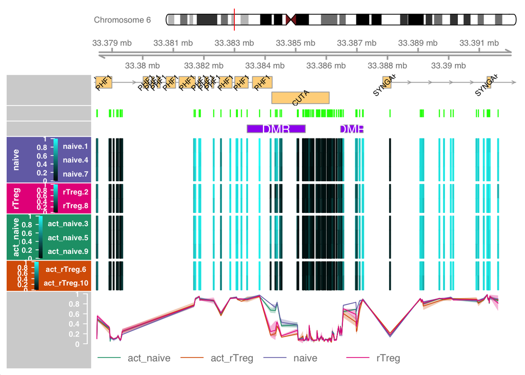

```r
par(mfrow=c(1,1))
DMR.plot(ranges = results.ranges, dmr = 2, CpGs = bVals, phen.col = cols,
         what = "Beta", arraytype = "450K", genome = "hg19")
```

```r
# Convert DMR ranges to a data frame
DMR_table <- as.data.frame(results.ranges)
DMR_table
```

```
##     seqnames     start       end width strand no.cpgs min_smoothed_fdr
## 1       chr3 114012316 114012912   597      *       5    3.036770e-181
## 2       chr6  33383412  33385314  1903      *      14    1.068041e-162
## 3       chr1  12188502  12188637   136      *       3    1.995722e-132
## 4       chr6 149805995 149806732   738      *      10    1.140890e-118
## 5       chr1  27440463  27440721   259      *       3    4.487724e-117
## 6      chr18  21452730  21453131   402      *       7    1.549552e-115
## 7      chr16  89421700  89422212   513      *       7    6.988026e-115
## 8      chr12  89743788  89745192  1405      *      11    3.341425e-110
## 9       chr1 156784152 156786010  1859      *       6    1.181278e-107
## 10     chr12   6485537   6487080  1544      *      10    1.132154e-105
## 11      chr4   3371236   3373555  2320      *      14     3.248102e-98
## 12     chr15  29212889  29213860   972      *       7     4.263018e-98
## 13      chr1  16301562  16302461   900      *       5     8.874338e-98
## 14     chr17  75370611  75371764  1154      *       4     1.942673e-96
```

[output cut: 1602 more lines]